# Estimating Subnational Micronutrient Deficiency Prevalence from Proxy Indicators: A Multi-Country SuperLearner Ensemble Approach

Author

Affiliation

Micronutrient Prediction Consortium

University of California Davis, Institute for Global Nutrition

Published

March 29, 2026

# Abstract

**Background.** Vitamin and mineral deficiencies affect over two billion people globally, yet biomarker survey data remain sparse due to the cost and logistical burden of nationally representative micronutrient status surveys. Subnational prevalence estimates are critical for targeting large-scale food fortification programs and monitoring progress, but few countries have district-level biomarker data.

**Methods.** We developed a SuperLearner ensemble machine learning pipeline to estimate subnational prevalence of vitamin A deficiency (VAD) and iron deficiency in children (6–59 months) and women of reproductive age (15–49 years) across four West and Southern African countries: Gambia, Ghana, Sierra Leone, and Malawi. Models used exclusively proxy predictors drawn from 13 open data sources—including satellite imagery, climate data, agricultural statistics, malaria surfaces, DHS survey indicators, and food security indices—without relying on biomarker data from the same survey. We assessed within-country discrimination using cluster-blocked five-fold cross-validation, quantified subnational prediction accuracy at the Admin-2 (district) level, evaluated cross-country transportability through leave-one-country-out (LOCO) analysis, and generated out-of-sample predictions for an unsurveyed country (Cote d’Ivoire) with weighted conformal prediction intervals.

**Conclusions.** Proxy-only SuperLearner ensembles can produce informative subnational estimates of micronutrient deficiency prevalence in data-rich settings, achieving moderate to good discrimination for vitamin A deficiency and iron deficiency. However, cross-country transportability remains a challenge, and rare outcomes (prevalence below 3%) require careful handling. This approach offers a scalable framework for filling critical data gaps in micronutrient surveillance, complementing rather than replacing biomarker surveys.

# 1 Introduction

Micronutrient deficiencies—often termed “hidden hunger”—constitute one of the most widespread forms of malnutrition globally. An estimated two billion people suffer from inadequate intake or absorption of essential vitamins and minerals, with vitamin A deficiency, iron deficiency anaemia, iodine deficiency, and zinc deficiency accounting for the greatest burden of morbidity and mortality in low- and middle-income countries. Young children and women of reproductive age bear a disproportionate share of this burden, with consequences ranging from impaired immune function and increased child mortality to adverse birth outcomes and reduced cognitive development.

Despite the scale and severity of micronutrient deficiencies, reliable prevalence data remain remarkably scarce. Nationally representative micronutrient status surveys that include biochemical biomarker assessment are expensive, logistically demanding, and infrequent. Many countries in sub-Saharan Africa have conducted at most one or two national micronutrient surveys in the past two decades, and subnational estimates at the district or province level are available for even fewer. This pervasive data gap hampers the design, targeting, and monitoring of nutrition interventions—particularly large-scale food fortification programs, which require geographically specific prevalence estimates to optimize coverage and assess impact.

The policy landscape increasingly demands subnational granularity. The Scaling Up Nutrition (SUN) movement, the Global Alliance for Improved Nutrition (GAIN), and national fortification programs all require district-level data to allocate resources efficiently and track progress toward global nutrition targets. The 2024 Global Nutrition Report highlights persistent inequalities in micronutrient status both between and within countries, yet the evidence base for subnational variation relies heavily on modeled estimates rather than direct measurement.

Several approaches have been proposed to address this data gap. Geostatistical models, such as those developed by the Malaria Atlas Project for malaria parasite rate mapping, exploit spatial autocorrelation to interpolate between survey clusters but require dense sampling networks that are rarely available for micronutrient outcomes. Small-area estimation techniques borrow strength across areas by linking survey data to census or administrative covariates, but typically require a contemporaneous census and may not generalize well across national boundaries. Direct survey weighting can produce Admin-1 (region) level estimates but often yields unstable estimates at finer spatial scales due to small sample sizes.

Machine learning offers an alternative paradigm. Rather than relying on spatial smoothing or parametric assumptions about the relationship between covariates and outcomes, ensemble methods such as SuperLearner can flexibly combine multiple prediction algorithms to identify the best-performing weighted combination for a given prediction task. Crucially, machine learning models can incorporate high-dimensional covariate sets drawn from diverse open data sources—satellite imagery, climate reanalysis products, agricultural statistics, demographic surveys, and food security databases—that may serve as proxy indicators for micronutrient status. If the relationship between these proxy indicators and true micronutrient deficiency prevalence is sufficiently strong and stable, such models could fill critical data gaps at a fraction of the cost of new biomarker surveys.

In this study, we develop and evaluate a SuperLearner ensemble prediction pipeline for estimating subnational prevalence of vitamin A deficiency and iron deficiency among children aged 6–59 months and women of reproductive age (15–49 years). We draw on nationally representative micronutrient surveys from four countries in West and Southern Africa—The Gambia (2018), Ghana (2017), Sierra Leone (2013), and Malawi (2015–16)—and construct a predictor architecture comprising over 200 variables from 13 open data sources, deliberately excluding all biomarker and same-survey health variables to ensure a strictly proxy-only approach.

Our objectives are fourfold: (1) to assess the within-country predictive performance of proxy-only SuperLearner models for four micronutrient deficiency outcomes using cluster-blocked cross-validation; (2) to evaluate the accuracy of model-based subnational prevalence estimates at the Admin-2 (district) level against design-based survey estimates; (3) to test cross-country transportability through leave-one-country-out validation; and (4) to demonstrate out-of-sample prediction with uncertainty quantification for an unsurveyed country (Cote d’Ivoire) using weighted conformal prediction intervals.

# 2 Methods

## 2.1 Study design and data sources

This study used a retrospective, cross-sectional design linking individual-level biomarker data from four nationally representative micronutrient surveys to area-level proxy predictors from open data sources. The four surveys were:

- **The Gambia National Nutrition Survey (GMNS, 2018):** Population-based survey of children 6–59 months and women 15–49 years with retinol-binding protein (RBP) and ferritin biomarkers.
- **Ghana Micronutrient Survey (GMS, 2017):** National survey with RBP-based vitamin A assessment and ferritin-based iron status indicators for children and women.
- **Sierra Leone Micronutrient Survey (SLMS, 2013):** National survey with RBP measurement in children and women; ferritin in children only.
- **Malawi Micronutrient Survey (MNS, 2015–16):** National survey with vitamin A and iron biomarker assessment across multiple population groups.

Table 1: Descriptive summary of study populations by country and outcome

[output not shown]

## 2.2 Predictor architecture

We assembled a high-dimensional predictor set from 13 open data sources, mapped to individual survey records via spatial joins at the Admin-1 or Admin-2 level. Critically, all predictors from the same survey (prefix `gw_`) were excluded from primary models to prevent outcome leakage. The predictor architecture is summarized below:

Table 2: Data sources and predictor domains used in the SuperLearner ensemble

| Domain | Prefix | Source | Spatial Level |
| --- | --- | --- | --- |
| DHS indicators | dhs*_ | Demographic and Health Surveys (BYM2 smoothed) | Admin-1/2 |
| IHME estimates | ihme_ | Institute for Health Metrics and Evaluation | Admin-2 |
| MAP surfaces | MAP_ | Malaria Atlas Project (PfPR, ITN, treatment) | Admin-2 |
| Satellite indices | gee_ | Google Earth Engine (NDVI, LST, EVI, etc.) | Cluster buffer |
| Rainfall | chirps_ | CHIRPS precipitation | Admin-2 |
| Population | worldpop_ | WorldPop population density | Admin-2 |
| Nighttime lights | ntl_ | VIIRS nighttime luminosity | Admin-2 |
| Soil nutrients | soil_ | SoilGrids nutrient concentrations | Admin-2 |
| Development | gdl_ | Global Data Lab (HDI, education, health) | Admin-2 |
| Agriculture | crop_ | HarvestChoice/SPAM (crop area, yield) | Admin-2 |
| MICS indicators | mics_ | UNICEF Multiple Indicator Cluster Surveys | Admin-1 |
| Food security | fsec_ | HFID + Cadre Harmonise | Admin-1/2 |
| Food prices | wfp_ | WFP HungerMap (food consumption, coping) | Market |
| Conflict | acled_ | ACLED conflict event counts | Admin-2 |
| Food security | ipc_ | IPC phase classifications | Admin-2 |

After preprocessing—including near-zero variance filtering, correlation filtering (|r| > 0.85), missing value imputation with indicator variables, and marginal prescreening (p < 0.20)—models typically retained 50–150 proxy predictors per country–outcome combination.

## 2.3 SuperLearner ensemble

We used the SuperLearner (also known as stacking) framework implemented via the `mlr3` R package ecosystem. For each country–outcome combination, two ensembles were fitted: a continuous model predicting the biomarker concentration and a binary classification model predicting deficiency status.

### 2.3.1 Learner library

The candidate learner library comprised five algorithms:

1. **Intercept-only mean** (benchmark)
2. **Lasso regression** (glmnet, alpha = 1)
3. **Random forest** (ranger, min.node.size = 10)
4. **Gradient-boosted trees** (xgboost, max_depth = 3)
5. **Bayesian Additive Regression Trees** (BART, ntree = 100)

The metalearner was non-negative least squares (NNLS), which finds the optimal convex combination of base learner predictions.

### 2.3.2 Cross-validation design

All models were evaluated using five-fold cross-validation with cluster blocking: all individuals within the same survey primary sampling unit (PSU/cluster) were assigned to the same fold to prevent information leakage from spatial autocorrelation within clusters. Fold assignments were generated using `origami::make_folds(cluster_ids = ...)`.

## 2.4 Performance evaluation

### 2.4.1 Binary classification metrics

For binary outcomes, we report: (1) area under the receiver operating characteristic curve (ROC-AUC), (2) area under the precision-recall curve (PR-AUC), which is more informative than ROC-AUC for rare outcomes, (3) Brier score and Brier skill score (improvement over prevalence-only baseline), and (4) calibration slope and intercept from logistic regression of observed outcomes on logit-transformed predicted probabilities.

### 2.4.2 Continuous model metrics

For continuous outcomes, we report root mean squared error (RMSE), mean absolute error (MAE), coefficient of determination (R-squared), and Pearson correlation coefficient.

### 2.4.3 Subnational accuracy

Model predictions were aggregated to the Admin-2 (district) level using survey weights and compared to design-based survey-weighted prevalence estimates. Agreement was assessed via MAE (in percentage points), RMSE (pp), Pearson correlation, and mean bias.

## 2.5 Conformal prediction intervals

We constructed distribution-free prediction intervals using split conformal inference applied to cross-validated residuals. For each individual, the absolute residual |Y_i - Y_hat_i| from out-of-fold predictions was computed, and the (1 - alpha) quantile of these residuals defined a constant-width interval. A locally adaptive variant scaled interval width by the predicted variance, providing wider intervals where the model was less certain. Intervals were propagated to Admin-1 and national levels by aggregation.

## 2.6 Domain ablation

To assess the relative importance of predictor domains, we conducted permutation-based domain ablation. Variables were grouped into approximately 22 conceptual domains (e.g., Climate, Child Health, Malaria, Socioeconomic, Agriculture) based on DHS indicator classification and prefix matching. For each domain, we shuffled that domain’s columns across five replicates and measured the resulting degradation in AUC and Brier score relative to the full model.

## 2.7 Cross-country transportability

To evaluate whether models trained on a subset of countries could predict micronutrient deficiency in a held-out country, we conducted leave-one-country-out (LOCO) cross-validation. For each outcome, individual-level data from all four countries were pooled, restricting to common proxy predictors. A SuperLearner was trained on three countries and evaluated on the fourth, with AUC, Brier score, and calibration metrics reported for each held-out country.

## 2.8 Out-of-sample prediction

For Cote d’Ivoire—a country without a recent nationally representative micronutrient survey—we generated Admin-2 prevalence predictions using a pooled elastic net model trained on survey-weighted Admin-2 prevalence from all four training countries. Uncertainty was quantified using weighted conformal prediction intervals that account for covariate shift between training and target populations via density ratio estimation. Districts with covariate profiles dissimilar to the training distribution received appropriately wider prediction intervals.

# 3 Results

## 3.1 Binary classification performance

Table 3: Cross-validated binary classification performance across country–outcome models

[output not shown]

Note:  
ROC-AUC = area under the receiver operating characteristic curve; PR-AUC = area under the precision-recall curve; Cal. Int. = calibration intercept; Cal. Slope = calibration slope. AUC = 0.50 indicates degenerate models with no discrimination.

Brier skill scores were uniformly modest (0.05–0.21 among non-degenerate models), indicating that proxy-only models provided limited improvement over a prevalence-only baseline for individual-level prediction. However, the primary application of these models is area-level prevalence estimation rather than individual classification, where even modest individual-level discrimination can aggregate into useful subnational estimates.

## 3.2 Continuous model performance

Table 4: Cross-validated continuous model performance across country–outcome models

[output not shown]

Note:  
Prevalence columns expressed as percentages. R-squared and Pearson r are computed from cross-validated predictions. Prev. Bias = Predicted - Observed prevalence.

## 3.3 AUC forest plot

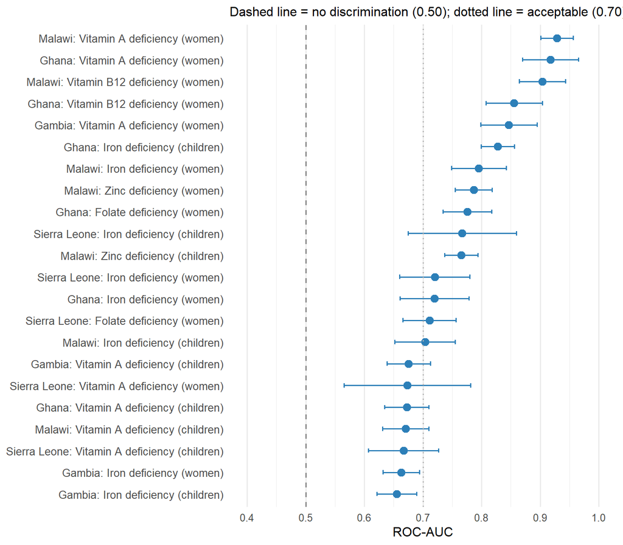

## 3.4 Admin-1 observed versus predicted scatter

[output not shown]

## 3.5 Admin-2 prediction accuracy

Table 5: Admin-2 (district-level) prediction accuracy: SuperLearner aggregated predictions versus survey-weighted prevalence

| Country | Outcome | N Admin-2 | MAE (pp) | RMSE (pp) | Pearson r | Mean Bias (pp) |
| --- | --- | --- | --- | --- | --- | --- |
| NA | Vitamin A deficiency (children) | 30 | 4.24 | 5.79 | 0.91 | 0.66 |
|  | Vitamin A deficiency (women) | 30 | 1.43 | 1.85 | 0.97 | 0.06 |
|  | Iron deficiency (children) | 30 | 3.24 | 4.70 | 0.97 | 0.07 |
|  | Iron deficiency (women) | 30 | 4.74 | 6.89 | 0.92 | -0.18 |
| Ghana | Vitamin A deficiency (children) | 75 | 7.53 | 9.86 | 0.73 | 0.99 |
|  | Vitamin A deficiency (women) | 75 | 1.54 | 2.38 | 0.83 | 0.19 |
|  | Iron deficiency (children) | 75 | 4.40 | 6.72 | 0.93 | 0.42 |
|  | Iron deficiency (women) | 75 | 4.73 | 6.23 | 0.81 | 1.26 |
|  | Folate deficiency (women) | 75 | 11.69 | 14.89 | 0.90 | -0.25 |
|  | Vitamin B12 deficiency (women) | 75 | 6.30 | 9.43 | 0.88 | -0.23 |
| Sierra Leone | Vitamin A deficiency (children) | 14 | 3.43 | 4.26 | 0.84 | 0.38 |
|  | Vitamin A deficiency (women) | 14 | 1.47 | 1.73 | 0.67 | 0.70 |
|  | Iron deficiency (children) | 14 | 1.62 | 2.13 | 0.90 | 0.25 |
|  | Iron deficiency (women) | 14 | 1.70 | 2.05 | 0.96 | 0.18 |
|  | Folate deficiency (women) | 14 | 3.04 | 3.91 | 0.94 | -0.91 |
|  | Vitamin B12 deficiency (women) | 14 | 0.64 | 0.69 | -0.31 | 0.10 |
| Malawi | Vitamin A deficiency (children) | 87 | 7.20 | 9.42 | 0.74 | -0.07 |
|  | Vitamin A deficiency (women) | 87 | 2.45 | 3.81 | 0.85 | -0.03 |
|  | Iron deficiency (children) | 87 | 6.21 | 8.00 | 0.74 | -0.25 |
|  | Iron deficiency (women) | 87 | 4.63 | 6.07 | 0.90 | 0.27 |
|  | Folate deficiency (women) | 87 | 0.14 | 1.34 | NA | -0.14 |
|  | Vitamin B12 deficiency (women) | 87 | 2.57 | 3.38 | 0.89 | 0.25 |
|  | Zinc deficiency (children) | 87 | 7.91 | 10.58 | 0.94 | 0.25 |
|  | Zinc deficiency (women) | 87 | 9.17 | 11.76 | 0.94 | -1.28 |

Note:  
pp = percentage points. Pearson r computed across Admin-2 units. Positive mean bias indicates model overpredicts relative to survey.

## 3.6 Cross-country transportability

| Held-Out Country | N (train) | N (test) | Test Prevalence | AUC | Brier | Cal. Int. | Cal. Slope | Outcome |
| --- | --- | --- | --- | --- | --- | --- | --- | --- |
| Gambia | 2753 | 1020 | 26.1 | 0.629 | 0.192 | 1.932 | 2.184 | child_vitA |
| Ghana | 2608 | 1165 | 20.6 | 0.586 | 0.162 | -0.141 | 0.773 | child_vitA |
| Sierra Leone | 3287 | 486 | 18.3 | 0.504 | 0.245 | -1.541 | -1.317 | child_vitA |
| Malawi | 2671 | 1102 | 19.9 | 0.537 | 0.171 | -0.990 | 0.479 | child_vitA |
| Gambia | 2586 | 1413 | 3.0 | 0.728 | 0.029 | -33.289 | -8.160 | women_vitA |
| Ghana | 2994 | 1005 | 1.3 | 0.573 | 0.013 | -2.077 | 0.675 | women_vitA |
| Sierra Leone | 3225 | 774 | 2.3 | 0.572 | 0.023 | -1.481 | 0.749 | women_vitA |
| Malawi | 3192 | 807 | 2.1 | 0.562 | 0.021 | -5.645 | -0.535 | women_vitA |
| Gambia | 2747 | 1013 | 42.0 | 0.519 | 0.258 | -0.627 | -0.365 | child_iron |
| Ghana | 2601 | 1159 | 17.9 | 0.643 | 0.148 | -0.154 | 1.261 | child_iron |
| Sierra Leone | 3274 | 486 | 5.8 | 0.479 | 0.229 | -2.766 | 0.293 | child_iron |
| Malawi | 2658 | 1102 | 9.7 | 0.517 | 0.099 | -2.024 | 0.145 | child_iron |
| Gambia | 2720 | 1402 | 31.2 | 0.626 | 0.246 | -2.256 | -0.999 | women_iron |
| Ghana | 3036 | 1086 | 7.6 | 0.467 | 0.095 | -2.062 | 0.345 | women_iron |
| Sierra Leone | 3295 | 827 | 8.8 | 0.535 | 0.093 | -2.804 | -0.300 | women_iron |
| Malawi | 3315 | 807 | 10.2 | 0.519 | 0.092 | -2.428 | -0.122 | women_iron |

Note:  
LOCO: train on 3 countries, predict on held-out country. Negative calibration slopes indicate reversed prediction direction.

## 3.7 National prevalence estimates with conformal intervals

[output not shown]

# 4 Discussion

## 4.2 The proxy-only approach: capabilities and limitations

A distinctive feature of our approach is the strict exclusion of all same-survey variables from primary models. This proxy-only constraint ensures that the models can, in principle, be applied to geographic areas and time periods without biomarker survey coverage. The trade-off is lower predictive accuracy compared to models that incorporate individual-level health indicators from the same survey.

The modest Brier skill scores (0.05–0.21) indicate that, at the individual level, proxy-only models offer limited improvement over simply predicting the population prevalence for every individual. However, individual-level discrimination is not the primary goal; rather, the aggregation of weakly informative individual predictions across clusters and districts can produce area-level estimates that capture meaningful geographic variation, as evidenced by the strong Admin-2 correlations in Ghana.

## 4.6 Strengths

The study has several notable strengths. The multi-country design with standardized pipeline infrastructure enables systematic comparison across contexts. The proxy-only constraint ensures methodological rigor and practical applicability. The diverse predictor architecture—drawing from 13 open data sources spanning satellite imagery, climate, agriculture, demographics, health, and food security—captures multiple pathways through which population-level micronutrient status is determined. The conformal prediction intervals provide distribution-free uncertainty quantification that does not rely on parametric assumptions or computationally intensive resampling. The entire pipeline is implemented as a reproducible `targets` workflow, facilitating extension to additional countries and outcomes.